# proposal

Ziqi Tang

2021/10/27

[Download this file as a template](http://adamwilson.us/SpatialDataScience/scripts/Project_ProposalTemplate.Rmd).

# Introduction to problem/question

The Kyoto Protocol divides the world’s countries into two categories in terms of carbon emissions, one is rich countries and the other is developing countries. The agreement stipulates that the former will reduce emissions, while the latter will not bear the obligation of emission reduction due to the needs of economic development. After the entry into force of the Kyoto Protocol in 1997, the carbon emissions of Europe, the United States and other rich countries and regions did slow down and GDP continued to grow rapidly. However, the carbon emissions of developing countries increased explosively, and the speed of GDP development was lower than those of these rich countries.

### Problem / Question

Is there any difference in the change of annual emissions in different countries and the relationship between emissions and GDP?

# Inspiring Examples

## Example 1

[figure not shown]

https://www.cgdev.org/media/developing-countries-are-responsible-63-percent-current-carbon-emissions

I found this graphic easy to understand the percent of annual emissions which countries produce. This type of graphic could be used to illustrate the proportion of different sectors using simple ‘Piechart’ in ggplot.

## Example 2

[figure not shown]

https://ourworldindata.org/grapher/consumption-co2-per-capita?tab=chart&time=1800..2018&country=~CHN

## Example 3

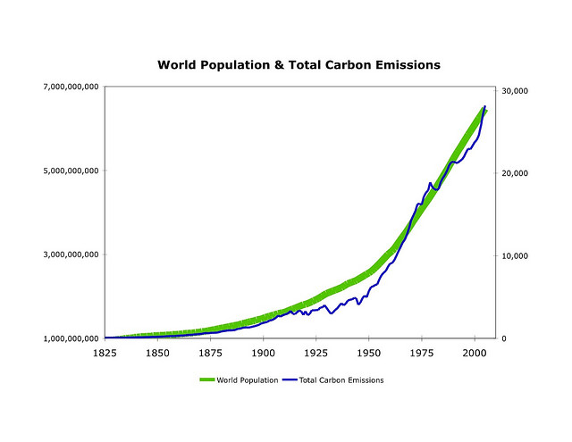

https://courses.lumenlearning.com/boundless-statistics/chapter/correlation/

I found this graphic easy to understand the correlation between the population and carbon emissions. This type of graphic could be used to reflect the correlation between CO2 and greenhouse emissions in different countries using package ‘correlation’.

# Proposed data sources

CO2 emissions: this data is sourced from the Global Carbon Project.

Greenhouse gas emissions (including methane, and nitrous oxide): this data is sourced from the CAIT Climate Data Explorer, and downloaded from the Climate Watch Portal.

Population & GDP

# Proposed methods

1. Read data by “read_csv” function.
2. Divide the data into the following categories: United States, European Union, Japan, Russia, other high-come developed countries, China, India, Middle East & North Africa, Latin America, other developing Asia, etc.
3. Use “piechart” to reflect the percent of annual emissions of different countries.
4. Use “geom_line” to reflect the changes in annual emissions, CO2 and GDP.
5. Use “correlation” to show the relation coefficients of different countries.

# Expected results

1. Piechart showing the percentage of annual emissions in different countries.
2. Graph showing the changes of annual emissions, CO2, and GDP in 2000, 2004, 2008, 2012.
3. Graph showing the relation coefficients of different countries.